# Physician Acceptance of a Physician‐Pharmacist Collaborative Treatment Model for Hypertension Management in Primary Care - Smith - 2015 - The Journal of Clinical Hypertension - Wiley Online Library

[The Journal of Clinical Hypertension](https://onlinelibrary.wiley.com/journal/17517176)

[Volume 17, Issue 9](https://onlinelibrary.wiley.com/toc/17517176/2015/17/9) p. 686-691

[figure not shown]

Original Paper

Free Access

# Physician Acceptance of a Physician-Pharmacist Collaborative Treatment Model for Hypertension Management in Primary Care

[Steven M. Smith PharmD, MPH](https://onlinelibrary.wiley.com/action/doSearch?ContribAuthorRaw=Smith%2C+Steven+M),

[Michaela Hasan PharmD](https://onlinelibrary.wiley.com/action/doSearch?ContribAuthorRaw=Hasan%2C+Michaela),

[Amy G. Huebschmann MD](https://onlinelibrary.wiley.com/action/doSearch?ContribAuthorRaw=Huebschmann%2C+Amy+G),

[Richard Penaloza MD](https://onlinelibrary.wiley.com/action/doSearch?ContribAuthorRaw=Penaloza%2C+Richard),

[Wagner Schorr-Ratzlaff MD](https://onlinelibrary.wiley.com/action/doSearch?ContribAuthorRaw=Schorr-Ratzlaff%2C+Wagner),

[Amber Sieja MD](https://onlinelibrary.wiley.com/action/doSearch?ContribAuthorRaw=Sieja%2C+Amber),

… See all authors

First published: 01 June 2015

https://doi.org/10.1111/jch.12575

Citations: 7

## Abstract

Physician-pharmacist collaborative care (PPCC) is effective in improving blood pressure (BP) control, but primary care provider (PCP) engagement in such models has not been well-studied. The authors analyzed data from PPCC referrals to 108 PCPs, for patients with uncontrolled hypertension, assessing the proportion of referral requests approved, disapproved, and not responded to, and reasons for disapproval. Of 2232 persons with uncontrolled hypertension, PPCC referral requests were sent for 1516 (67.9%): 950 (62.7%) were approved, 406 (26.8%) were disapproved, and 160 (10.6%) received no response. Approval rates differed widely by PCP with a median approval rate of 75% (interquartile range, 41%–100%). The most common reasons for disapproval were: PCP prefers to manage hypertension (19%), and BP controlled per PCP (18%); 8% of cases were considered too complex for PPCC. Provider acceptance of a PPCC hypertension clinic was generally high and sustained but varied widely among PCPs. No single reason for disapproval predominated.

Hypertension affects an estimated 1 billion adults globally and is the leading preventable cause of death worldwide.1, 2 Population-level control of hypertension has improved in many countries in recent decades, yet control rates remain suboptimal worldwide.3-6 Consequently, increased focus has been placed on health services research to identify cost-effective models to improve blood pressure (BP) control. One such model that is gaining increased attention in recent years is collaborative or team-based care where patients are managed by two or more providers from different disciplines (eg, a physician and pharmacist, or a physician and nurse). The addition of a pharmacist to the treatment team, in particular, has been shown to be broadly effective in reducing BP and improving BP control.7-11 For example, in a cluster-randomized trial of 402 patients with uncontrolled hypertension at baseline, a physician-pharmacist collaborative care (PPCC) model resulted in greater than twice the control rate of standard care from a primary care physician (64% vs 30% control rates, respectively; *P*<.001) after 6 months of treatment.7 Adjusting for baseline factors and medication adherence, the PPCC model was associated with 3.2 higher odds of achieving BP control compared with the standard care group.

PPCC models have been most often employed using clinical pharmacists in the primary care setting where the majority of patients with hypertension are actively managed. Once patients are referred to such a model, physicians tend to have a very high (95%) level of agreement with pharmacist recommendations for hypertension management, particularly when the clinical pharmacist is housed within the primary care clinic.12 However, the extent to which primary care providers (PCPs) participate with their patients in such models is not well established. Accordingly, we aimed to determine provider acceptance of a newly initiated PPCC hypertension clinic at two primary care clinics, each with a clinical pharmacist, as evidenced by approval rates of patient referral requests. In addition, we sought to identify the primary reasons for disapproval of patient referral requests. We hypothesized that acceptance of the PPCC model would be high and that acceptance would increase over time as providers gained familiarity with the service.

## Methods

### Study Design

We performed a prospective study of PCP acceptance of a newly developed PPCC for the management of hypertension in the primary care setting. Briefly, the PPCC was designed as a specialty hypertension clinic housed within the primary care setting for patients with uncontrolled BP. Each of the two primary care clinics were academic-based internal medicine clinics. Patients referred to the PPCC clinic were scheduled for an initial visit with an academic clinical pharmacist where the pharmacist assessed BP, previous and current drug therapy, and dietary and exercise habits. The pharmacist then developed an initial individualized treatment plan based on a BP treatment protocol that was modeled after the prevailing Joint National Committee Blood Pressure recommendations13 and developed in collaboration with the clinic PCPs. The plan was then reported to the patient's PCP, revised as needed, and approved. When possible, PPCC encounters were conducted on days that the PCP was available in the clinic to allow real-time discussion of the plan between the PCP and pharmacist. Additional follow-up then occurred via subsequent clinic visits or via telephone encounters, as needed. At subsequent encounters, medication management was performed by the pharmacist under the approved treatment protocol. The degree and extent of physician-pharmacist collaboration for each patient was at the discretion of the PCP and pharmacist. While receiving care in the PPCC, patients continued to see their PCP for routine care, including BP management, as needed.

Monthly automated reports were generated in the electronic health record to identify all patients who met criteria for referral to the PPCC hypertension clinic. Inclusion criteria were age 18 to 89 years, uncontrolled BP defined as BP ≥140/90 mm Hg at the most recent primary care clinic visit and an average BP ≥140/90 mm Hg during the most recent three visits within the previous 18 months, and at least one primary care visit at one of the two study clinics within the past 12 months. The monthly reports were then manually reviewed and patients were excluded if their hypertension was actively managed (within the previous 6 months) by a non-PCP (eg, nephrologist, cardiologist). Patients were not excluded based on the presence of any specific comorbidities. For patients meeting the aforementioned criteria, an order for referral to the PPCC clinic was pended to the patient's respective PCP in the electronic health record, notifying the PCP that the patient had met the predefined criteria for management in the PPCC clinic; ≤10 referral requests were sent per provider per month. The provider could approve the referral, indicating agreement with the patient being treated in the PPCC clinic, or disapprove the referral, indicating that they preferred the patient not be treated in the PPCC clinic. Providers were instructed that they could disapprove patients for any reason. For all disapproved referrals, the PCP was asked to provide a rationale, using a free text response, for disapproving the referral. For nonresponsive providers, reminder notifications were sent at approximately 2 and 4 weeks after the initial referral was placed. The study was approved by the Colorado Multiple Institutional Review Board.

### Data Collection

For patients meeting the aforementioned inclusion/exclusion criteria, data were collected from the electronic health record on all referrals placed for the PPCC clinic. These data included dates of referral placement and any subsequent reminders, PCP response (approval, disapproval, or nonresponse), and PCP rationale for disapprovals. Free text disapproval rationales were reviewed by study investigators and categorized by topic coding as one of the following: (1) hypertension being managed by a specialist (ie, cardiologist, nephrologist), (2) other care a priority, (3) patient case is too complex for PPCC, (4) patient currently controlled per PCP, (5) patient is new to the clinic (ie, lack of historical BP data), (6) patient is out of network or otherwise unable to come to appointments, (7) PCP prefers to manage hypertension themselves, (8) suspected or confirmed isolated clinic BP elevation (ie, “white-coat” hypertension), or (9) other rationale. For time trend data, we assessed what quarter of the year the referral request was originally placed to the PCP for hypertension management in the PPCC clinic (eg, quarter 1, quarter 2).

### Outcomes

The primary outcome was the proportion of individual patient referrals for treatment in the PPCC hypertension clinic that were accepted by PCPs. Secondary outcomes included reasons for disapproval of patient referral requests.

### Statistical Analyses

Descriptive statistics were used to characterize the study population and outcomes. Bivariate analyses comparing clinics were performed using the chi-square test. Comparisons within and between PCP type (ie, attending vs resident) were performed using nonparametric tests, including the Wilcoxon-Mann-Whitney and Kruskal-Willis tests; spearman correlation coefficients were used to assess the relationship between time in practice and approval rates among attending-level providers. Time trends in approval, disapproval, and nonresponse rates were analyzed using a generalized linear model. All analyses were performed using SAS 9.3 (SAS Institute, Cary, NC).

## Results

A total of 2232 patients with uncontrolled hypertension were identified from the monthly, automated reports between November 2012 and November 2013. After additional screening, 716 patients (32.1%) did not qualify for the following reasons: BP at most recent clinic visit (subsequent to screening report) was controlled (n=630; 88%); hypertension was managed by someone other than the PCP (n=75; 10.5%); or other (n=11; 1.5%). The remaining 1516 patients (67.9%) met inclusion criteria and all had referral requests sent to their respective providers (total=108). Approximately two thirds (n=1014) of these patients were cared for at the larger hospital-based academic clinic, whereas the remaining one third (n=502) were cared for at the smaller community-based academic clinic; however, the percentage of screened patients who qualified at each clinic were approximately equal (68.3% and 67.7%, respectively). Of the 108 PCPs who received at least one request, 56 (52%) were women and 45 (42%) were attendings, with a mean±standard deviation of 14.1±8.4 years in practice since completing a residency. The remaining 63 providers were residents; as of the end of the data collection period (November 2013), 21% were PGY1s, 33% were PGY2s, 22% were PGY3s, and 24% had completed their residency (ie, during the study period).

### Approvals, Disapprovals, and Nonresponse

Of the 1516 referral requests submitted, any response was received for 1356 (89.4%), whereas no response was received for 160 (10.6%). Response rates differed modestly by clinic. We received any response from 90.8% of requests to providers at the larger hospital-based clinic vs 86.7% for requests to providers at the smaller community-based clinic (*P*=.012). Response rates also varied by individual provider, ranging from 0% to 100%. Among all 108 providers, the median response rate was 100% (interquartile range [IQR], 83.9%–100%) and the median number of referral requests sent per provider was six (IQR, 3–25.5). The number of referral requests per provider was considerably greater among attendings (median, 30 [IQR 17–40]) than residents (median, 3 [IQR 2–6]; *P*<.0001 comparing attendings vs residents), but response rates were not significantly different (96% vs 100%, respectively; *P*=.057).

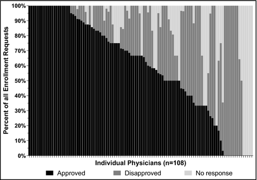

**Figure 1**

Open in figure viewer[PowerPoint](https://onlinelibrary.wiley.com/action/downloadFigures?id=jch12575-fig-0001&doi=10.1111%2Fjch.12575)

Approvals, disapprovals, and nonresponse by provider for all 108 providers.

No difference was observed in approval rates comparing attending PCPs (median approval rate, 59.5% [IQR 44.4%–78.3%]) and resident PCPs (71.4% [33.3%–100%]; *P*=.30). Among attending-level PCPs, we observed no significant correlation between years in practice (since completion of residency training) and percent of referral requests approved (ρ=.12; *P*=.45; Figure 2). Likewise, no difference in approval rates was observed comparing year of training (eg, PGY1–PGY3) for residents (*P*=.33).

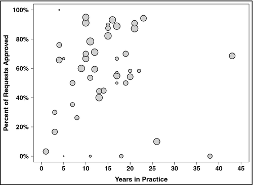

**Figure 2**

Open in figure viewer[PowerPoint](https://onlinelibrary.wiley.com/action/downloadFigures?id=jch12575-fig-0002&doi=10.1111%2Fjch.12575)

Percent of physician-pharmacist collaborative care clinic referrals approved among attending-level providers, according to years in practice. Data points are weighted according to the total number of referral requests sent, such that larger circles correspond to providers who received the greatest number of referral requests, whereas small circles represent those who received few requests.

### Rationales for Disapproval

Of the 406 disapprovals received, rationales were provided for 244 requests (60.1%). Disapproval rationales are summarized in Figure 3. The most common stated reasons for disapproval were that the PCP preferred to manage the patients BP on their own (19%) and that the patient's hypertension was controlled according to the PCP (eg, that a higher BP threshold for treatment was appropriate for the patient; 18%). Approximately one in 12 patients (8%) were considered too complex by their PCP to receive care in the PPCC hypertension clinic.

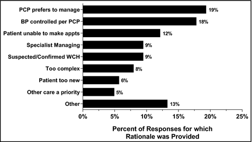

**Figure 3**

Open in figure viewer[PowerPoint](https://onlinelibrary.wiley.com/action/downloadFigures?id=jch12575-fig-0003&doi=10.1111%2Fjch.12575)

Provider rationales for disapproval from the PPCC hypertension clinic. Percentages represent the proportion of disapprovals with each respective rationale out of all disapprovals for which a rationale was provided (n=244). BP, blood pressure; PCP, primary care provider; WCH, white coat hypertension.

### Time Trends in Approval, Disapproval, and Nonresponse

Considering all 1516 referral requests analyzed by quarter, approval rates ranged from 59.7% in quarter 1 to 57.3% in quarter 4, with the peak approval rate of 78.4% occurring in quarter 2 (Figure 4). No significant time trends were observed with regard to approval or disapproval rates. However, nonresponse increased modestly over time from 6% in the first quarter to 16% in the final quarter (*P*<.0001).

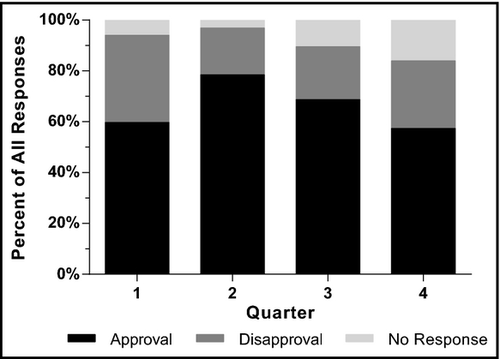

**Figure 4**

Open in figure viewer[PowerPoint](https://onlinelibrary.wiley.com/action/downloadFigures?id=jch12575-fig-0004&doi=10.1111%2Fjch.12575)

Approvals, disapprovals, and nonresponse over time.

## Discussion

PPCC models are known to effectively reduce BP and improve BP control in patients with hypertension.7, 8 However, the extent to which the PPCC model is accepted by PCPs and patients has not been well described. In the present study, we explored acceptance of the PPCC model by PCPs and observed a relatively high level of engagement among more than 100 PCPs from two primary care clinics. To our knowledge, this is the first study to provide detailed data on approval and disapproval rates, and reasons for disapprovals, for patients qualifying for PPCC for hypertension in the primary care setting where PPCC models exist most frequently.

Rationales for disapproval into the PPCC hypertension clinic varied considerably, with no single rationale exceeding 20% of all provided rationales. The most common stated reason for disapproval was that the provider preferred to manage their patient's hypertension without the clinical pharmacist. Interestingly, 18% of disapprovals occurred when the PCP considered BP controlled, despite the patient having an elevated BP (≥140/90 mm Hg) at the most recent visit and a mean BP ≥140/90 mm Hg over the prior three visits. This finding could be due to several factors, including lack of trust in clinic BP validity,18 provider disagreement with the Seventh Report of the Joint National Committee on Prevention, Detection, Evaluation, and Treatment of High Blood Pressure (JNC 7) criteria for BP goals,13 or suspected white-coat hypertension that was not reported explicitly as such. Curiously, 8% of disapprovals were for patients considered “too complex,” presumably the patients most likely to benefit from an interdisciplinary team-based care approach. Qualitative research to understand why certain PCPs prefer to manage hypertension on their own, especially in patients perceived as “overly complex,” may help optimize future versions of the PPCC model for hypertension or other chronic diseases.

Although approval and disapproval rates remained relatively stable throughout the study year, nonresponse rates increased modestly over time. The total number of providers not responding to any requests was small (n=5; 4.6%) and all but one of these providers received five or fewer referral requests. The reasons for nonresponse among these providers are not known, but these providers may simply have been unfamiliar with the requests or what should be done with them. Alternatively, some providers may have considered collaborative care to worsen fragmentation of care through the use of additional care providers, as has been documented in previous qualitative research.15 Nevertheless, these data suggest a need for ongoing efforts to maintain provider engagement and to identify barriers and concerns of PCPs for referring patients to a collaborative care clinic.

## Conclusions

These data suggest that, among our sample of 108 PCPs who were sent >1500 referrals, acceptance and engagement of a PPCC model was generally high and sustained for 1 year. Additional research is needed to identify common barriers to provider engagement and acceptance of PPCC models and to determine whether incorporating additional services into the PPCC model might improve provider uptake. For example, offering 24-hour ambulatory BP monitoring as part of the PPCC hypertension clinic19 may reduce disapprovals on behalf of patients with suspected white-coat hypertension. In addition, patient perceptions of and engagement in PPCC models will need to be further explored in future studies.

## Disclosures

This work was supported by a grant from the University of Colorado Hospital and University of Colorado School of Medicine Small Grants Program. During the period of this project, AGH was supported by National Institutes of Health/National Center for Advancing Translational Sciences Colorado Clinical and Translational Science Award grant number KL2 TR001080. The contents of this article are the authors' sole responsibility and do not necessarily represent official NIH views. The authors have no other conflicts of interest to disclose.

## Citing Literature

[figure not shown]

[Volume17, Issue9](https://onlinelibrary.wiley.com/toc/17517176/2015/17/9)

September 2015

Pages 686-691

### Recommended

[figure not shown]

[figure not shown]